# Problem Set 4 Melyssa & Luca

Luca

04/05/2021

# Melyssa - replication text

## May 3th, 2021

##### HOW POLITICAL PARTIES SHAPE PUBLIC OPINION IN THE REAL WORLD

##### AUTHORS: Martin Bisgaard & Rune Slothuus

##### VERSION: SEPTEMBER 2020

Research question & key references:  
How powerful are political parties in shaping citizen’s opinions? (i.e., How citizens react when their party changes its position on a major issue in the real world)

Hypotheses and corresponding diagram:  
Citizen’s policy opinions change when their party change its policy position: They assume that changes in opinions among treated and nontreated respondents would have been the same, had there not been a dramatic change in party positions.

Data & methods  
Quasi-experimental panel study of how citizens responded when their political party suddenly reversed its position on two major and salient welfare issues in Denmark.

Five-wave panel survey in the aftermath of the great recession in Denmark (2010-11) collected around the two following events (welfare policies):

- 50% reduction in a widely used unemployment insurance program.
- The abolition of a popular early retirement program.

They investigated what people thought about the cutback before and after their party proposed them.

Data: Epinion’s pool of respondents through random sample telephone surveys, population aged 18-65 years in Denmark.

Variables:

- Party affiliation
- Policy opinions
- Citizens opinions on either early retirement or unemployment benefits (outcome variable)

Causal effect of changing party positions as the difference between the policy opinions of citizens in a situation where their party has changed its position compared to a situation the party has not. For any individual, they can never observe both outcomes. They are forced to make assumptions to answer what citizens’ policy opinions would have looked like, had their party not changed its policy position. They use the change among citizens who identity with another party to approximate this unobserved counterfactual.

Difference-in-difference design

Treated group: respondents identifying with a party that changes its policy position

Nontreated group: respondents who identify with a party that did not change its position

They use repeated observations of the same citizens and not repeated cross-section with different citizens => this allows to study individual opinion change.

Expected results  
They show that citizens’ policy opinions changed immediately and substantially when their party switched its policy position, even when the new position went against citizens’ previously held opinion.

Contribution to political thought  
These findings advance the current experimental literature on partisan elite influence.

References  
Slothuus, R., & Bisgaard, M. (2020). How Political Parties Shape Public Opinion in the Real World. American Journal of Political Science.

### Replication

Install packages

```r
# install.packages("rio")
# install.packages("foreign")
# install.packages("car")
# install.packages("plyr")
# install.packages("plm")
# install.packages("lme4")
# install.packages("lmtest")
# install.packages("stargazer")
# install.packages("xtable")
# install.packages("psych")
# install.packages("grDevices")
# install.packages("plyr")
# install.packages("reshape2")
# install.packages("pBrackets")
# install.packages("MatchIt")
# install.packages("sandwich")
```

Load packages

```r
require(rio)
require(foreign)
require(car)
require(plyr)
require(plm)
require(lme4)
require(lmtest)
require(stargazer)
require(xtable)
require(psych)
require(grDevices)
require(plyr)
require(reshape2)
require(pBrackets)
require(MatchIt)
require(sandwich)
```

Import data set

```r
paneldata_long <- read.dta("Problem Set 4/01 Data/Slothuus&Birgaard (2020)/paneldata_long.dta")
paneldata_wide <- read.dta("Problem Set 4/01 Data/Slothuus&Birgaard (2020)/paneldata_wide.dta")
partypositions <- rio::import("Problem Set 4/01 Data/Slothuus&Birgaard (2020)/partypositions.sav")

dat.balance <- paneldata_long
paneldat <- paneldata_wide
dat.balance$partyAll<-recode(dat.balance$partyAll,'"NA"=NA') #fixing NA value on party variable
dat<-dat.balance
```

#### Analysis of party positions

```r
mediadata <- partypositions
dim(mediadata)
```

```
## [1] 762  28
```

```r
#how many articles? (number reported in footnote)
length(unique(mediadata$ID))
```

```
## [1] 646
```

```r
#how many coded parti positions? (number reported in footnote)
sum(table(unlist(mediadata[,22:28])))
```

```
## [1] 818
```

```r
#break up data file into each issue
retiredata <- mediadata[mediadata$issue==2,]
unempdata <- mediadata[mediadata$issue==1,]
dim(retiredata)
```

```
## [1] 542  28
```

```r
names(retiredata)
```

```
##  [1] "ID"      "tid"     "medie"   "issue"   "partiEL" "partiSF" "partiS"
##  [8] "partiRV" "partiK"  "partiV"  "partiDF" "posEL"   "posSF"   "posS"
## [15] "posRV"   "posK"    "posV"    "posDF"   "udeladt" "week"    "month"
## [22] "posELny" "posSFny" "posSny"  "posRVny" "posKny"  "posVny"  "posDFny"
```

```r
dim(unempdata)
```

```
## [1] 310  28
```

```r
names(unempdata)
```

```
##  [1] "ID"      "tid"     "medie"   "issue"   "partiEL" "partiSF" "partiS"
##  [8] "partiRV" "partiK"  "partiV"  "partiDF" "posEL"   "posSF"   "posS"
## [15] "posRV"   "posK"    "posV"    "posDF"   "udeladt" "week"    "month"
## [22] "posELny" "posSFny" "posSny"  "posRVny" "posKny"  "posVny"  "posDFny"
```

#### ISSUE: UNEMPLOYMENT BENEFIT PERIOD

```r
#Position of PM party + DPP
Vpos <- data.frame("tid"=unempdata$tid,"pos"=unempdata$posVny,"party"="V")
DPPpos<- data.frame("tid"=unempdata$tid,"pos"=unempdata$posDFny,"party"="DF")
treatment<-rbind(Vpos,DPPpos)

#CENTER-LEFT
SFpos <- data.frame("tid"=unempdata$tid,"pos"=unempdata$posSny,"party"="S")
Spos <- data.frame("tid"=unempdata$tid,"pos"=unempdata$posSFny,"party"="SF")
ELpos <- data.frame("tid"=unempdata$tid,"pos"=unempdata$posELny,"party"="EL")
centerLeft<-rbind(SFpos,Spos)

#CENTER-RIGHT
RVpos <- data.frame("tid"=unempdata$tid,"pos"=unempdata$posRVny,"party"="RV")
Kpos <- data.frame("tid"=unempdata$tid,"pos"=unempdata$posKny,"party"="K")
centerRight<-rbind(RVpos,Kpos)


#clean and convert date variable
treatment$date <- as.Date(as.character(treatment$tid),"%Y%m%d")
centerLeft$date <- as.Date(as.character(centerLeft$tid),"%Y%m%d")
centerRight$date <- as.Date(as.character(centerRight$tid),"%Y%m%d")

#remove '0' from vector (0 = position is not present in article)
treatment$pos[treatment$pos==0]<-NA
centerLeft$pos[centerLeft$pos==0]<-NA
centerRight$pos[centerRight$pos==0]<-NA

#drop NA cases
treatment   <-  na.omit(treatment)
centerLeft  <-  na.omit(centerLeft)
centerRight <-  na.omit(centerRight)
dim(treatment)
```

```
## [1] 102   4
```

```r
dim(centerLeft)
```

```
## [1] 60  4
```

```r
dim(centerRight)
```

```
## [1] 51  4
```

## REPRODUCING FIGURE 1

```r
pdf("benefitsCue.pdf",width=6,height=4)

cols1=rgb(.1,.1,1,alpha=.175)
cols2=rgb(1,.1,.1,alpha=.175)
cols3=rgb(0,.1,0,alpha=.1)

par(omd=c(.1,1,0,1))
plot(treatment$date,jitter(treatment$pos),col="white",yaxt='n',ylab="",xlab="",ylim=c(.5,5.5),xlim=c(as.Date("2010-01-01"),as.Date("2011-03-01")),xaxt='n')
axis(2,at=1:5,las=2,labels=c("Oppose","Partly\noppose","Ambiguous","Partly\nsupport","Support"),cex.axis=.8)
m<-smooth.spline(treatment$pos~treatment$date,spar=1)
lines(m,lwd=1.5)
m<-smooth.spline(centerLeft$pos~centerLeft$date,spar=1)
lines(m,lwd=1.5,col="grey60")
m<-smooth.spline(centerRight$pos~centerRight$date,spar=1)
lines(m,lwd=1.5,lty=2,col="grey60")
text(x=as.Date("2010-06-01"),y=3.4,label="Liberals\nDPP",cex=.8)
text(x=as.Date("2010-10-01"),y=2.4,label="Social Democrats\nSPP",cex=.8,col="grey60")
text(x=as.Date("2010-03-15"),y=5,label="Conservatives\nSocial Liberals",cex=.8,col="grey60")
rng<-par("usr")
rect(15015,rng[3],rng[2],rng[4],col="grey90")
mtext(4,line=-1.35,text="Reduce Unemp. Benefits")

dens<-c(centerRight$date,centerLeft$date,treatment$date)
rug(dens)

dev.off()
```

### PARTY POSITIONS ON OTHER ISSUE: ABOLISHING EARLY RETIREMENT

```r
#Position of PM party (liberals)
treatment <- data.frame("tid"=retiredata$tid,"pos"=retiredata$posVny,"party"="V")

#Position of CENTER LEFT opposition + DPP
SFpos <- data.frame("tid"=retiredata$tid,"pos"=retiredata$posSny,"party"="S")
Spos <- data.frame("tid"=retiredata$tid,"pos"=retiredata$posSFny,"party"="SF")
DPPpos <- data.frame("tid"=retiredata$tid,"pos"=retiredata$posDFny,"party"="DF")
centerLeft<-rbind(SFpos,Spos,DPPpos)

#Position of CENTER RIGHT
RVpos <- data.frame("tid"=retiredata$tid,"pos"=retiredata$posRVny,"party"="RV")
Kpos <- data.frame("tid"=retiredata$tid,"pos"=retiredata$posKny,"party"="K")
centerRight<-rbind(RVpos,Kpos)



#clean and convert date variable
centerLeft$date <- as.Date(as.character(centerLeft$tid),"%Y%m%d")
centerRight$date <- as.Date(as.character(centerRight$tid),"%Y%m%d")
treatment$date<-as.Date(as.character(treatment$tid),"%Y%m%d")

#remove missing data
treatment<-na.omit(treatment)
centerLeft  <-  na.omit(centerLeft)
centerRight <-  na.omit(centerRight)

#remove 0's
centerLeft$pos[centerLeft$pos==0]<-NA
centerRight$pos[centerRight$pos==0]<-NA
treatment$pos[treatment$pos==0]<-NA

cols3=rgb(0,.1,0,alpha=.1)

pdf("retireCue.pdf",width=6,height=4)
cols1=rgb(.1,.1,1,alpha=.175)
cols2=rgb(1,.1,.1,alpha=.175)
par(omd=c(.1,1,0,1))
plot(treatment$date,jitter(treatment$pos),col="white",yaxt='n',ylab="",xlab="",ylim=c(.5,5.5),xlim=c(as.Date("2010-01-01"),as.Date("2011-03-01")),xaxt='n')
axis(2,at=1:5,las=2,labels=c("Oppose","Partly\noppose","Ambiguous","Partly\nsupport","Support"),cex.axis=.8)
axis.Date(1,at=seq(as.Date("2010-01-01"),as.Date("2011-01-01"), by="month"), format="%b",las=1,cex.axis=.8)
axis.Date(1,at=c(as.Date("2010-01-01"),as.Date("2011-01-01")), format="%Y",las=1,line=1,tick="FALSE",cex.axis=.8)
m<-smooth.spline(treatment$pos~treatment$date,spar=1)
lines(m,lwd=1.5)
m<-smooth.spline(centerLeft$pos~centerLeft$date,spar=1)
lines(m,lwd=1.5,col="grey60")
m<-smooth.spline(centerRight$pos~centerRight$date,spar=1)
lines(m,lwd=1.5,col="grey60",lty=2)

rng<-par("usr")
rect(15015,rng[3],rng[2],rng[4],col="grey90")
mtext(4,line=-1.35,text="Abolish Early Retirement")
text(x=as.Date("2010-11-01"),y=3.5,label="Liberals",cex=.8)
text(x=as.Date("2010-07-01"),y=1,label="Social Democrats\nSPP and DPP",cex=.8,col="grey60")
text(x=as.Date("2010-5-01"),y=5,label="Conservatives\nSocial Liberals",cex=.8,col="grey60")

dens<-c(centerRight$date,centerLeft$date,treatment$date)
rug(dens)

dev.off()
```

## REPRODUCING FIGURE 2

```r
pdf("timeline.pdf",height=2,width=6)

par(mai=c(.1,.1,.1,.1),omd=c(0,1,0,1),mfrow=c(1,1),lend=1)
period<-seq(as.Date("2010-01-01"),as.Date("2011-07-01"), by="month")
plot(0,axes=FALSE,ann=FALSE,xlim=c(as.Date("2010-01-01"),as.Date("2011-07-01")))
lines(c(as.Date("2010-01-01"),as.Date("2011-07-01")),c(.5,.5),lty=2)
lines(c(as.Date("2010-01-01"),as.Date("2010-01-01")),c(.55,.45))
lines(c(as.Date("2011-01-01"),as.Date("2011-01-01")),c(.55,.45))
text(as.Date("2010-01-01"),.7,"2010")
text(as.Date("2011-01-01"),.7,"2011")

for (i in 1:length(period)) lines(rep(period[i],2),c(.525,.475))
mn<-format(period,'%b')
mn[13]<-NA
text(x=period,y=rep(.38,length(period)),mn,cex=.5)

t=8
tc=rgb(0,.1,0,alpha=.4)
lines(c(as.Date("2010-02-17"),as.Date("2010-02-26")),c(.5,.5),lwd=t,col=tc)
lines(c(as.Date("2010-03-26"),as.Date("2010-04-12")),c(.5,.5),lwd=t,col=tc)
lines(c(as.Date("2010-06-09"),as.Date("2010-06-21")),c(.5,.5),lwd=t,col=tc)
lines(c(as.Date("2011-01-05"),as.Date("2011-01-16")),c(.5,.5),lwd=t,col=tc)
lines(c(as.Date("2011-06-20"),as.Date("2011-06-30")),c(.5,.5),lwd=t,col=tc)
lines(c(as.Date("2010-05-19"),as.Date("2010-05-19")),c(.5,.1),lty=1)
text(as.Date("2010-05-19"),.1,"Liberals and DPP reverse policy position,\nproposing to cut the unemployment benefit\nperiod from four to two years",pos=1,cex=.8,xpd=T)
lines(c(as.Date("2011-01-03"),as.Date("2011-01-03")),c(.5,-.4),lty=1)
text(as.Date("2011-01-20"),-.4,"Liberals reverse policy position, proposing to\nabolish the early retirement program",pos=1,cex=.8)
text(as.Date("2010-03-05"),.8,"Fielding period of panel waves",cex=.8,pos=4)
segments(as.Date("2010-02-27"),0.55,as.Date("2010-03-15"),.75)

dev.off()
```

### Response rates reported in section “Panel Survey Data and Measures”

```r
#the calculated response rate (55%) reported in text was obtained from the polling Company, Epinion.

#re-contact acceptance rate (reported in text)
prop.table(table(paneldat$recontact))[1]
```

```
##         1
## 0.8077188
```

```r
#calculation of completion rate (reported in text)
prop.table(table(paneldat$completion))[2]
```

```
##         1
## 0.4155755
```

### Descriptives on measures reported in Data and Design section

```r
#how many partisans identify with a party that changes position?
table(dat$partyAll[dat$completion==1]%in%c("V"))/5  #ID with liberals
```

```
##
## FALSE  TRUE
##   997   209
```

```r
prop.table(table(dat$partyAll[dat$completion==1]%in%c("V"))) #percent
```

```
##
##     FALSE      TRUE
## 0.8266998 0.1733002
```

```r
table(dat$partyAll[dat$completion==1]%in%c("DF"))/5 #ID with DPP
```

```
##
## FALSE  TRUE
##  1123    83
```

```r
prop.table(table(dat$partyAll[dat$completion==1]%in%c("DF")))   #percent
```

```
##
##      FALSE       TRUE
## 0.93117745 0.06882255
```

```r
#distribution on DVs (for whole sample)
mean(dat.balance$benefitClean,na.rm=T)
```

```
## [1] 0.4165131
```

```r
sd(dat.balance$benefitClean,na.rm=T)
```

```
## [1] 0.3832946
```

```r
table(dat$benefit)[6]/sum(table(dat$benefit))
```

```
##          6
## 0.02776948
```

```r
mean(dat$retire_cutClean,na.rm=T)
```

```
## [1] 0.5257091
```

```r
sd(dat$retire_cutClean,na.rm=T)
```

```
## [1] 0.3798087
```

```r
table(dat$retire_cut)[6]/sum(table(dat$retire_cut))
```

```
##          6
## 0.03503533
```

## REPRODUCING FIGURE 3

```r
#balancing panel
dat.balance<-dat
dat.balance<-dat.balance[!dat.balance$id %in% (dat.balance[is.na(dat.balance$benefitClean)|is.na(dat.balance$partyAll),]$id),]
dim(dat.balance)
```

```
## [1] 4955   92
```

```r
## matched control group ##
covariates<-c("pressure","education","sex","unemployed","age","income","benefitW1","benefitW2")
dat_match<-dat.balance[,c(covariates,"partyAll","id","time")]
dat_match<-dat_match[unique(dat_match$id)&dat_match$time==1,] #return to "wide" format
dat_match<-na.omit(dat_match)
dat_match$treated<-recode(dat_match$partyAll,'"V"=1;"DF"=1;else=0') #code treatment group vs. control pool
table(dat_match$treated)
```

```
##
##   0   1
## 691 266
```

```r
#get rid of danish letters on values on covariates
dat_match$income<-as.numeric(as.factor(dat_match$income))
dat_match$education<-as.factor(as.numeric(as.factor(dat_match$education)))

match <- matchit(treated ~factor(education)+pressure+unemployed+sex+age+factor(income)+factor(benefitW1)+factor(benefitW2),
                 method = "nearest", data = dat_match)

#summary(match)
#plot(match)

dta_m<-match.data(match)
matchID<-dta_m$id[dta_m$treated==0] #store ID of matched control group

## calculate quantities of interest for plotting

dat.balance$partygroup<-recode(dat.balance$partyAll,'"V"=1;"DF"=1;else=0')
dat.balance$partygroup<-factor(dat.balance$partygroup)
table(dat.balance$partygroup)/5
```

```
##
##   0   1
## 718 273
```

```r
dat.balance$partygroup_matched<-recode(dat.balance$partyAll,'"V"=1;"DF"=1;else=NA')
dat.balance$partygroup_matched[dat.balance$id%in%matchID] <- 0

#calculate quantities of interest
SE=function(x)sd(x)/sqrt(length(x)-1) #function to calculate naive SEs
out<-aggregate(benefitClean~partygroup*time,data=dat.balance,mean)
out.se<-aggregate(benefitClean~partygroup*time,data=dat.balance,SE)

outm<-aggregate(benefitClean~partygroup_matched*time,data=dat.balance,mean)
outm.se<-aggregate(benefitClean~partygroup_matched*time,data=dat.balance,SE)
```

## PLOTTING

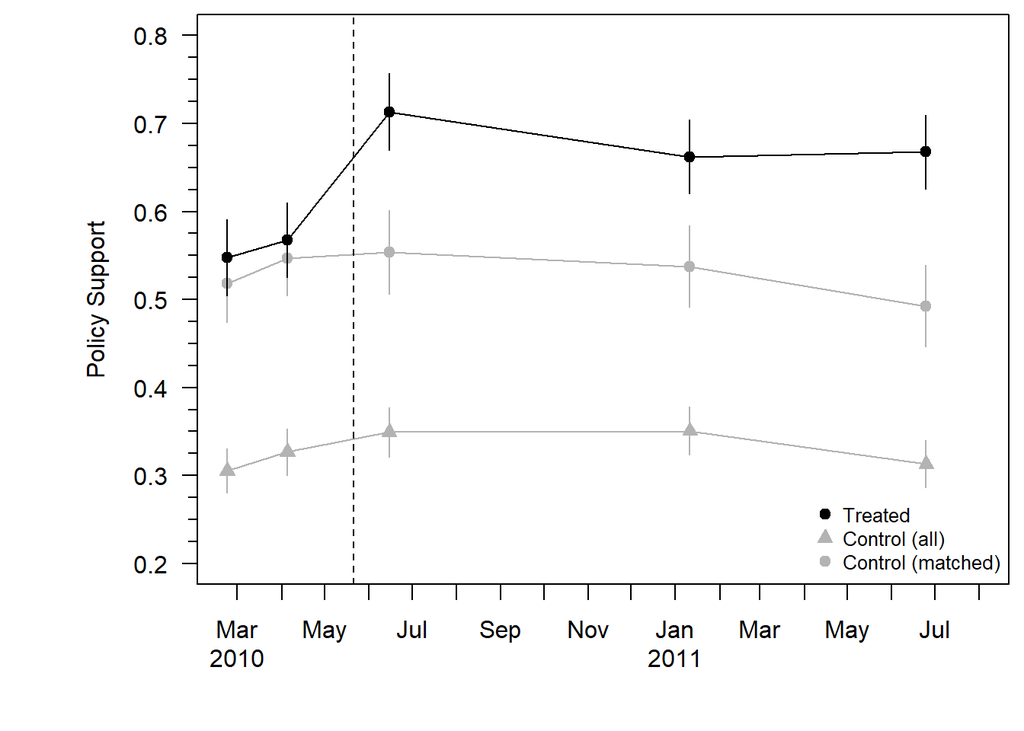

```r
#sets correct spacing between waves
x<-c("2010-02-22","2010-04-05","2010-06-15","2011-01-11","2011-06-25")
x<-as.Date(x)


c1="grey70"

#pdf('benefits_plot.pdf',width=6,height=4)
par(omd=c(0.05,1,0,1),mai=c(1,1,.1,.1),mfrow=c(1,1))
y=out[out$partygroup==1,3]
se=out.se[out.se$partygroup==1,3]
plot(x,y,ylim=c(.2,.8),xlim=c(x[1],as.Date("2011-08-01")),main="",xaxt="n",yaxt="n",ylab="",xlab="")
segments(x,y+1.96*se,x,y-1.96*se)
lines(x,y,lty=1)
points(x,y,pch=21,bg="black")
y=out[out$partygroup==0,3]
se=out.se[out.se$partygroup==0,3]
lines(x,y,lty=1,col=c1)
points(x,y,pch=24,bg=c1,col=c1)
segments(x,y+1.96*se,x,y-1.96*se,col=c1)
y=outm[outm$partygroup==0,3]
se=outm.se[outm.se$partygroup==0,3]
lines(x,y,lty=1,col=c1)
points(x,y,pch=21,bg=c1,col=c1)
segments(x,y+1.96*se,x,y-1.96*se,col=c1)

#redraw CI's of treatment group (for overlap)
y=out[out$partygroup==1,3]
se=out.se[out.se$partygroup==1,3]
segments(x,y+1.96*se,x,y-1.96*se)
points(x,y,pch=21,bg="black")

axis(2,las=2)
axis(2,at=seq(0,1,.025),tck=-.015,labels=NA)
mtext(2,text="Policy Support",line=3)
axis.Date(1,at=seq(as.Date("2010-03-01"),as.Date("2011-08-01"), by="month"),format="%b",las=1,cex.axis=1)
axis.Date(1,at=c(as.Date("2010-03-01"),as.Date("2011-01-01")),format="%Y",las=1,cex.axis=1,line=1,tick="FALSE")
abline(v=as.Date("2010-05-21"),lty=2)

legend('bottomright',pch=c(21,24,21),pt.bg=c("black",c1,c1),col=c("black",c1,c1),legend=c("Treated","Control (all)","Control (matched)"),cex=.8,pt.cex=1,bty='n')
```

```r
dev.off()
```

### Change among DPP and Liberals

Note: Exact numbers are not referenced in text, but the analysis is referred to

```r
out_lib<-aggregate(benefitClean~time,data=dat.balance[dat.balance$partyAll=="V",],mean)
out_dpp<-aggregate(benefitClean~time,data=dat.balance[dat.balance$partyAll=="DF",],mean)

out_dpp[3,2]-out_dpp[2,2] #change among DPP
```

```
## [1] 0.1466667
```

```r
out_lib[3,2]-out_lib[2,2] #change among liberals
```

```
## [1] 0.145202
```

```r
out[6,3]-out[4,3]     #aggregate
```

```
## [1] 0.1456044
```

```r
####
# no. of obs
# reported in caption of figure

table(dat.balance$partygroup)
```

```
##
##    0    1
## 3590 1365
```

```r
table(dat.balance$partygroup_matched)
```

```
##
##    0    1
## 1330 1365
```

```r
(table(dat.balance$partygroup)/5)
```

```
##
##   0   1
## 718 273
```

```r
(table(dat.balance$partygroup_matched)/5)
```

```
##
##   0   1
## 266 273
```

```r
#####
# PLACEBO DID (reported in footnote)

pfit1<-plm(benefitClean~time*partygroup,data=dat.balance[dat.balance$time%in%c(1,2),],model="pooling",index=c("id","time"))
coeftest(pfit1, vcov=vcovHC(pfit1,cluster="group"))[4,]
```

```
##     Estimate   Std. Error      t value     Pr(>|t|)
## -0.001093034  0.018198862 -0.060060579  0.952113454
```

```r
####
# FD among Lib and DPP voters (reported in text)

pfit1<-plm(benefitClean~time,data=dat.balance[dat.balance$time%in%c(2,3)&dat.balance$partygroup==1,],model="pooling",index=c("id","time"))

coef(pfit1)[1]  #level before change in policy position
```

```
## (Intercept)
##   0.5677656
```

```r
sum(coef(pfit1))    #level after change in policy position
```

```
## [1] 0.71337
```

```r
coeftest(pfit1, vcov=vcovHC(pfit1,cluster="group"))[2,] #change
```

```
##     Estimate   Std. Error      t value     Pr(>|t|)
## 1.456044e-01 2.044393e-02 7.122132e+00 3.382849e-12
```

## Reproducing results in Table 1

DiD models

```r
pfit1<-plm(benefitClean~partygroup*time,data=dat.balance[dat.balance$time%in%c(2,3),],model="pooling",index=c("id","time"))
pfit1_out<-coeftest(pfit1,vcov=vcovHC(pfit1,cluster="group"))["partygroup1:time3",]
eff1<-pfit1_out[1]
se1<-pfit1_out[2]

pfit2<-plm(benefitClean~partygroup*time+retire_cutClean+bb+ub,data=dat.balance[dat.balance$time%in%c(2,3),],model="pooling",index=c("id","time"))
pfit2_out<-coeftest(pfit2,vcov=vcovHC(pfit2,cluster="group"))["partygroup1:time3",]
eff2<-pfit2_out[1]
se2<-pfit2_out[2]

pfit3<-plm(benefitClean~partygroup_matched*time,data=dat.balance[dat.balance$time%in%c(2,3),],model="pooling",index=c("id","time"))
pfit3_out<-coeftest(pfit3,vcov=vcovHC(pfit3,cluster="group"))["partygroup_matched:time3",]
eff3<-pfit3_out[1]
se3<-pfit3_out[2]

pfit4<-plm(benefitClean~partygroup_matched*time+retire_cutClean+bb+ub,data=dat.balance[dat.balance$time%in%c(2,3),],model="pooling",index=c("id","time"))
pfit4_out<-coeftest(pfit4,vcov=vcovHC(pfit4,cluster="group"))["partygroup_matched:time3",]
eff4<-pfit4_out[1]
se4<-pfit4_out[2]


#constructing table
parenth <- function(x){paste0(paste0("(",x),")")} #small function for putting parentheses around numbers

tab<-round(cbind(pfit1_out,pfit2_out,pfit3_out,pfit4_out),2)[1:2,]
tab[2,]<-parenth(tab[2,])
rownames(tab)<-c("DiD","")
colnames(tab)<-rep("",ncol(tab))

obs<-cbind(pdim(pfit1)$nT[-2],pdim(pfit2)$nT[-2],pdim(pfit3)$nT[-2],pdim(pfit4)$nT[-2])
rownames(obs)<-c("Units","Observations")

stargazer(rbind(tab,obs))
```

```
##
## % Table created by stargazer v.5.2.2 by Marek Hlavac, Harvard University. E-mail: hlavac at fas.harvard.edu
## % Date and time: Wed, May 05, 2021 - 15:05:15
## \begin{table}[!htbp] \centering
##   \caption{}
##   \label{}
## \begin{tabular}{@{\extracolsep{5pt}} ccccc}
## \\[-1.8ex]\hline
## \hline \\[-1.8ex]
##  & .1 & .2 & .3 & .4 \\
## \hline \\[-1.8ex]
## DiD & 0.12 & 0.11 & 0.14 & 0.12 \\
##  & (0.02) & (0.02) & (0.03) & (0.03) \\
## Units & 991 & 985 & 539 & 539 \\
## Observations & 1982 & 1941 & 1078 & 1067 \\
## \hline \\[-1.8ex]
## \end{tabular}
## \end{table}
```

```r
#note: appearance of table has been edited manually


#p-values reported in text
pfit1_out
```

```
##     Estimate   Std. Error      t value     Pr(>|t|)
## 1.229721e-01 2.312398e-02 5.317946e+00 1.168128e-07
```

```r
pfit3_out
```

```
##     Estimate   Std. Error      t value     Pr(>|t|)
## 1.390254e-01 2.844471e-02 4.887569e+00 1.176326e-06
```

## Reproducing Figure 4

```r
#balancing panel for the issue
dat.balance<-dat
dat.balance<-dat.balance[!dat.balance$id %in% (dat.balance[is.na(dat.balance$retire_cutClean)|is.na(dat.balance$partyAll),]$id),]
dim(dat.balance)
```

```
## [1] 4880   92
```

```r
## matched control group ##
covariates<-c("unemployed","pressure","education","sex","age","income","retireW1","retireW2","retireW3")
dat_match<-dat.balance[,c(covariates,"partyAll","id","time")]
dat_match<-dat_match[unique(dat_match$id)&dat_match$time==1,] #return to "wide" format
dat_match<-na.omit(dat_match)
dat_match$treated<-recode(dat_match$partyAll,'"V"=1;else=0') #code treatment group vs. control pool
table(dat_match$treated)
```

```
##
##   0   1
## 753 194
```

```r
#get rid of danish letters on values on covariates
dat_match$income<-as.numeric(as.factor(dat_match$income))
dat_match$education<-as.factor(as.numeric(as.factor(dat_match$education)))

match <- matchit(treated ~ factor(retireW1)+factor(retireW2)+factor(retireW3)+pressure+sex+unemployed+factor(income)+factor(education)+age,
                 method = "nearest", data = dat_match)

#summary(match)
#plot(match)

dta_m<-match.data(match)
matchID<-dta_m$id[dta_m$treated==0] #store ID of matched control group

## calculate quantities of interest for plotting

dat.balance$partygroup<-recode(dat.balance$partyAll,'"V"=1;else=0')
dat.balance$partygroup<-factor(dat.balance$partygroup)

dat.balance$partygroup_matched<-recode(dat.balance$partyAll,'"V"=1;else=NA')
dat.balance$partygroup_matched[dat.balance$id%in%matchID] <- 0

#calculate quantities of interest
SE=function(x)sd(x)/sqrt(length(x)-1) #function to calculate naive SEs
out<-aggregate(retire_cutClean~partygroup*time,data=dat.balance,mean)
out.se<-aggregate(retire_cutClean~partygroup*time,data=dat.balance,SE)

outm<-aggregate(retire_cutClean~partygroup_matched*time,data=dat.balance,mean)
outm.se<-aggregate(retire_cutClean~partygroup_matched*time,data=dat.balance,SE)
```

## PLOTTING

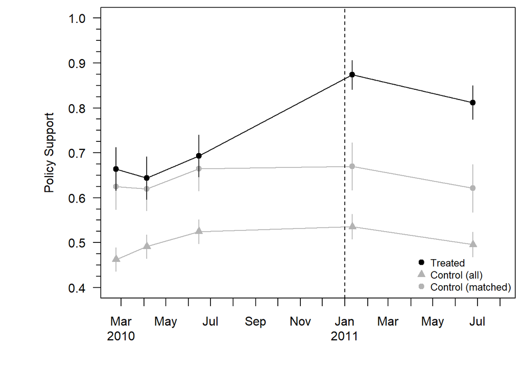

```r
c1="grey70"

#pdf('retire_plot.pdf',width=6,height=4)

par(omd=c(0.05,1,0,1),mai=c(1,1,.1,.1),mfrow=c(1,1))
y=out[out$partygroup==1,3]
se=out.se[out.se$partygroup==1,3]
plot(x,y,ylim=c(.4,1),xlim=c(x[1],as.Date("2011-08-01")),main="",xaxt="n",yaxt="n",ylab="",xlab="")
segments(x,y+1.96*se,x,y-1.96*se)
lines(x,y,lty=1)
points(x,y,pch=21,bg="black")
y=out[out$partygroup==0,3]
se=out.se[out.se$partygroup==0,3]
lines(x,y,lty=1,col=c1)
points(x,y,pch=24,bg=c1,col=c1)
segments(x,y+1.96*se,x,y-1.96*se,col=c1)
y=outm[outm$partygroup==0,3]
se=outm.se[outm.se$partygroup==0,3]
lines(x,y,lty=1,col=c1)
points(x,y,pch=21,bg=c1,col=c1)
segments(x,y+1.96*se,x,y-1.96*se,col=c1)

#redraw CI's of treatment group (for overlap)
y=out[out$partygroup==1,3]
se=out.se[out.se$partygroup==1,3]
segments(x,y+1.96*se,x,y-1.96*se)
points(x,y,pch=21,bg="black")

axis(2,las=2)
axis(2,at=seq(0,1,.025),tck=-.015,labels=NA)
mtext(2,text="Policy Support",line=3)
axis.Date(1,at=seq(as.Date("2010-03-01"),as.Date("2011-08-01"), by="month"),format="%b",las=1,cex.axis=1)
axis.Date(1,at=c(as.Date("2010-03-01"),as.Date("2011-01-01")),format="%Y",las=1,cex.axis=1,line=1,tick="FALSE")
abline(v=as.Date("2011-01-01"),lty=2)
legend('bottomright',pch=c(21,24,21),pt.bg=c("black",c1,c1),col=c("black",c1,c1),legend=c("Treated","Control (all)","Control (matched)"),cex=.8,pt.cex=1,bty='n')
```

```r
dev.off()
```

```r
####
# number of observations (reported in caption for figure 4)

table(dat.balance$partygroup)
```

```
##
##    0    1
## 3890  990
```

```r
table(dat.balance$partygroup_matched)
```

```
##
##   0   1
## 970 990
```

```r
table(dat.balance$partygroup)/5
```

```
##
##   0   1
## 778 198
```

```r
table(dat.balance$partygroup_matched)/5
```

```
##
##   0   1
## 194 198
```

```r
####
# reported change

out<-aggregate(retire_cutClean~time,data=dat.balance[dat.balance$partyAll=="V",],mean)
out[3,2] #pre
```

```
## [1] 0.6931818
```

```r
out[4,2] #post
```

```
## [1] 0.8737374
```

```r
##
# placebo DiD (reported in footnote)

pfit1<-plm(retire_cutClean~partygroup*time,data=dat.balance[dat.balance$time%in%c(1,2),],model="pooling",index=c("id","time"))
coeftest(pfit1,vcov=vcovHC(pfit1,cluster="group"))[4,]
```

```
##    Estimate  Std. Error     t value    Pr(>|t|)
## -0.04912233  0.01961928 -2.50377817  0.01236872
```

```r
pfit1<-plm(retire_cutClean~partygroup*time,data=dat.balance[dat.balance$time%in%c(2,3),],model="pooling",index=c("id","time"))
coeftest(pfit1,vcov=vcovHC(pfit1,cluster="group"))[4,]
```

```
##   Estimate Std. Error    t value   Pr(>|t|)
## 0.01582340 0.01990713 0.79486102 0.42679118
```

## Reporducing table 2

```r
pfit1<-plm(retire_cutClean~partygroup*time,data=dat.balance[dat.balance$time%in%c(3,4),],model="pooling",index=c("id","time"))
pfit1_out<-coeftest(pfit1,vcov=vcovHC(pfit1,cluster="group"))["partygroup1:time4",]
eff1<-pfit1_out[1]
se1<-pfit1_out[2]

pfit2<-plm(retire_cutClean~partygroup*time+benefitClean+bb+ub,data=dat.balance[dat.balance$time%in%c(3,4),],model="pooling",index=c("id","time"))
pfit2_out<-coeftest(pfit2,vcov=vcovHC(pfit2,cluster="group"))["partygroup1:time4",]
eff2<-pfit2_out[1]
se2<-pfit2_out[2]

pfit3<-plm(retire_cutClean~partygroup_matched*time,data=dat.balance[dat.balance$time%in%c(3,4),],model="pooling",index=c("id","time"))
pfit3_out<-coeftest(pfit3,vcov=vcovHC(pfit3,cluster="group"))["partygroup_matched:time4",]
eff3<-pfit3_out[1]
se3<-pfit3_out[2]

pfit4<-plm(retire_cutClean~partygroup_matched*time+benefitClean+bb+ub,data=dat.balance[dat.balance$time%in%c(3,4),],model="pooling",index=c("id","time"))
pfit4_out<-coeftest(pfit4,vcov=vcovHC(pfit4,cluster="group"))["partygroup_matched:time4",]
eff4<-pfit4_out[1]
se4<-pfit4_out[2]


#constructing table
parenth <- function(x){paste0(paste0("(",x),")")} #small function for putting parentheses around numbers

tab<-round(cbind(pfit1_out,pfit2_out,pfit3_out,pfit4_out),2)[1:2,]
tab[2,]<-parenth(tab[2,])
rownames(tab)<-c("DiD","")
colnames(tab)<-rep("",ncol(tab))

obs<-cbind(pdim(pfit1)$nT[-2],pdim(pfit2)$nT[-2],pdim(pfit3)$nT[-2],pdim(pfit4)$nT[-2])
rownames(obs)<-c("Units","Observations")

stargazer(rbind(tab,obs)) #note: appearance of table has been edited manually
```

```
##
## % Table created by stargazer v.5.2.2 by Marek Hlavac, Harvard University. E-mail: hlavac at fas.harvard.edu
## % Date and time: Wed, May 05, 2021 - 15:05:16
## \begin{table}[!htbp] \centering
##   \caption{}
##   \label{}
## \begin{tabular}{@{\extracolsep{5pt}} ccccc}
## \\[-1.8ex]\hline
## \hline \\[-1.8ex]
##  & .1 & .2 & .3 & .4 \\
## \hline \\[-1.8ex]
## DiD & 0.17 & 0.19 & 0.18 & 0.18 \\
##  & (0.02) & (0.02) & (0.03) & (0.03) \\
## Units & 976 & 975 & 392 & 391 \\
## Observations & 1952 & 1933 & 784 & 778 \\
## \hline \\[-1.8ex]
## \end{tabular}
## \end{table}
```

```r
#p-values reported in text
pfit1_out
```

```
##     Estimate   Std. Error      t value     Pr(>|t|)
## 1.696301e-01 2.290996e-02 7.404208e+00 1.953333e-13
```

### PARTY CUE EFFECTS CONDITIONAL ON PRIOR POLICY SUPPORT

```r
#distribution of policy opinons among Liberal and DPP voters in wave 2 (reported in text)

#ISSUE: UNEMPLOYMENT BENEFITS
dat.balance<-dat
tab1<-table(dat.balance$benefit[dat.balance$partyAll%in%c("V","DF")&dat.balance$time==2])

tab1    #frequencies
```

```
##
##   1   2   3   4   5   6
## 112 134  80  54  98  11
```

```r
prop.table(tab1) #percentages
```

```
##
##          1          2          3          4          5          6
## 0.22903885 0.27402863 0.16359918 0.11042945 0.20040900 0.02249489
```

```r
sum(tab1[4:5]) #how many opposes policy proposal
```

```
## [1] 152
```

```r
sum(tab1)   # total
```

```
## [1] 489
```

```r
sum(tab1[4:5])/sum(tab1) # percentage
```

```
## [1] 0.3108384
```

```r
#ISSUE: EARLY RETIREMENT
tab1<-table(dat.balance$retire_cut[dat.balance$partyAll=="V"&dat.balance$time==3])
tab1    #frequencies
```

```
##
##   1   2   3   4   5   6
## 130  83  47  31  34   7
```

```r
prop.table(tab1) #percentages
```

```
##
##          1          2          3          4          5          6
## 0.39156627 0.25000000 0.14156627 0.09337349 0.10240964 0.02108434
```

```r
sum(tab1[4:5]) #how many opposes
```

```
## [1] 65
```

```r
sum(tab1)   # total
```

```
## [1] 332
```

```r
sum(tab1[4:5])/sum(tab1) # percentage
```

```
## [1] 0.1957831
```

## Reproducing Figure 5

```r
dat.balance<-dat[!is.na(dat$partyAll),]
dim(dat.balance)
```

```
## [1] 12570    92
```

```r
dat.balance$benefitW2<-recode(dat.balance$benefitW2,'6=NA')

## matched control group ##
covariates<-c("pressure","education","sex","unemployed","age","income","benefitW1","benefitW2")
dat_match<-dat.balance[,c(covariates,"partyAll","id","time")]
dat_match<-dat_match[unique(dat_match$id)&dat_match$time==1,] #return to "wide" format
dat_match<-na.omit(dat_match)
dat_match$treated<-recode(dat_match$partyAll,'"V"=1;"DF"=1;else=0') #code treatment group vs. control pool
table(dat_match$treated)
```

```
##
##    0    1
## 1165  460
```

```r
#get rid of danish letters on values on covariates
dat_match$income<-as.numeric(as.factor(dat_match$income))
dat_match$education<-as.factor(as.numeric(as.factor(dat_match$education)))

match <- matchit(treated ~factor(education)+pressure+unemployed+sex+age+factor(income)+factor(benefitW1)+factor(benefitW2),
                 method = "nearest", data = dat_match)

#summary(match)
#plot(match)

dta_m<-match.data(match)
matchID<-dta_m$id[dta_m$treated==0] #store ID of matched control group

## calculate quantities of interest for plotting

dat.balance$partygroup_matched<-recode(dat.balance$partyAll,'"V"=1;"DF"=1;else=NA')
dat.balance$partygroup_matched[dat.balance$id%in%matchID] <- 0

#fit model
fit<-plm(benefitClean~partygroup_matched*time*factor(benefitW2),data=dat.balance[dat.balance$time%in%2:3,],index=c("id","time"),model="within")

#retrieve quantities of interest from panel model
cf<-coef(fit)
vmat<-vcovHC(fit,cluster="group")

did_est<-c(cf[2],cf[2]+cf[7],cf[2]+cf[8],cf[2]+cf[9],cf[2]+cf[10])
did_se<-c(sqrt(vmat[2,2]),sqrt(vmat[2,2]+vmat[7,7]+2*vmat[2,7]),
          sqrt(vmat[2,2]+vmat[8,8]+2*vmat[2,8]),
          sqrt(vmat[2,2]+vmat[9,9]+2*vmat[2,9]),
          sqrt(vmat[2,2]+vmat[10,10]+2*vmat[10,2]))

#means for plotting (levels etc)
benefit<-aggregate(benefitClean~partygroup_matched*time*factor(benefitW2),data=dat.balance[dat.balance$time%in%2:3,],mean)
```

### Effect among voters who supported cutbacks (reported in text)

```r
coeftest(fit,vcovHC(fit,cluster="group"))[2,]
```

```
##    Estimate  Std. Error     t value    Pr(>|t|)
## 0.093617154 0.034293106 2.729911767 0.006477605
```

```r
###########
# Effect among voters who opposed cutbacks (reported in text)

dat.balance$benefitW2f<-as.factor(dat.balance$benefitW2)
dat.balance$benefitW2f<-relevel(dat.balance$benefitW2f,ref='5')

fit<-plm(benefitClean~partygroup_matched*time*benefitW2f,data=dat.balance[dat.balance$time%in%2:3,],index=c("id","time"),model="within")
coeftest(fit,vcovHC(fit,cluster="group"))[2,]
```

```
##     Estimate   Std. Error      t value     Pr(>|t|)
## 1.963748e-01 4.920565e-02 3.990900e+00 7.201363e-05
```

```r
####
# ISSUE: EARLY RETIREMENT

dat.balance$retireW3<-recode(dat.balance$retireW3,'6=NA')

## matched control group ##
covariates<-c("pressure","education","unemployed","sex","age","income","retireW1","retireW2","retireW3")
dat_match<-dat.balance[,c(covariates,"partyAll","id","time")]
dat_match<-dat_match[unique(dat_match$id)&dat_match$time==1,] #return to "wide" format
dat_match<-na.omit(dat_match)
dat_match$treated<-recode(dat_match$partyAll,'"V"=1;else=0') #code treatment group vs. control pool
table(dat_match$treated)
```

```
##
##    0    1
## 1082  298
```

```r
#get rid of danish letters on values on covariates
dat_match$income<-as.numeric(as.factor(dat_match$income))
dat_match$education<-as.factor(as.numeric(as.factor(dat_match$education)))

match <- matchit(treated ~ factor(retireW1)+factor(retireW2)+factor(retireW3)+pressure+sex+unemployed+factor(income)+factor(education)+age,
                 method = "nearest", data = dat_match)


#summary(match)
#plot(match)

dta_m<-match.data(match)
matchID<-dta_m$id[dta_m$treated==0] #store ID of matched control group

## calculate quantities of interest for plotting

dat.balance$partygroup_matched<-recode(dat.balance$partyAll,'"V"=1;else=NA')
dat.balance$partygroup_matched[dat.balance$id%in%matchID] <- 0

#fit model
fit2<-plm(retire_cutClean~partygroup_matched*time*factor(retireW3),data=dat.balance[dat.balance$time%in%3:4,],index=c("id","time"),model="within")
summary(fit2)
```

```
## Oneway (individual) effect Within Model
##
## Call:
## plm(formula = retire_cutClean ~ partygroup_matched * time * factor(retireW3),
##     data = dat.balance[dat.balance$time %in% 3:4, ], model = "within",
##     index = c("id", "time"))
##
## Unbalanced Panel: n = 623, T = 1-2, N = 1149
##
## Residuals:
##      Min.   1st Qu.    Median   3rd Qu.      Max.
## -0.484954 -0.049242  0.000000  0.049242  0.484954
##
## Coefficients:
##                                             Estimate Std. Error t-value
## time4                                      -0.086022   0.025161 -3.4188
## partygroup_matched:time4                    0.055929   0.034325  1.6294
## time4:factor(retireW3)2                    -0.012463   0.039053 -0.3191
## time4:factor(retireW3)3                     0.150124   0.046290  3.2431
## time4:factor(retireW3)4                     0.219950   0.052305  4.2051
## time4:factor(retireW3)5                     0.237807   0.052305  4.5465
## partygroup_matched:time4:factor(retireW3)2  0.172838   0.053847  3.2098
## partygroup_matched:time4:factor(retireW3)3  0.193922   0.063695  3.0445
## partygroup_matched:time4:factor(retireW3)4  0.258059   0.075724  3.4079
## partygroup_matched:time4:factor(retireW3)5  0.301901   0.074468  4.0541
##                                             Pr(>|t|)
## time4                                      0.0006787 ***
## partygroup_matched:time4                   0.1038444
## time4:factor(retireW3)2                    0.7497512
## time4:factor(retireW3)3                    0.0012587 **
## time4:factor(retireW3)4                    3.076e-05 ***
## time4:factor(retireW3)5                    6.802e-06 ***
## partygroup_matched:time4:factor(retireW3)2 0.0014111 **
## partygroup_matched:time4:factor(retireW3)3 0.0024495 **
## partygroup_matched:time4:factor(retireW3)4 0.0007058 ***
## partygroup_matched:time4:factor(retireW3)5 5.809e-05 ***
## ---
## Signif. codes:  0 '***' 0.001 '**' 0.01 '*' 0.05 '.' 0.1 ' ' 1
##
## Total Sum of Squares:    25.062
## Residual Sum of Squares: 15.19
## R-Squared:      0.39391
## Adj. R-Squared: -0.34844
## F-statistic: 33.5357 on 10 and 516 DF, p-value: < 2.22e-16
```

```r
#retrieve quantities of interest from panel model
cf2<-coef(fit2)
vmat2<-vcovHC(fit2,cluster="group")

did_est2<-c(cf2[2],cf2[2]+cf2[7],cf2[2]+cf2[8],cf2[2]+cf2[9],cf2[2]+cf2[10])
did_se2<-c(sqrt(vmat2[2,2]),sqrt(vmat2[2,2]+vmat2[7,7]+2*vmat2[2,7]),
           sqrt(vmat2[2,2]+vmat2[8,8]+2*vmat2[2,8]),
           sqrt(vmat2[2,2]+vmat2[9,9]+2*vmat2[2,9]),
           sqrt(vmat2[2,2]+vmat2[10,10]+2*vmat2[10,2]))

#means for plotting (levels etc)
retire<-aggregate(retire_cutClean~partygroup_matched*time*factor(retireW3),data=dat.balance[dat.balance$time%in%3:4,],mean)
```

### Effect among voters who supported cutbacks (reported in text)

```r
coeftest(fit2,vcovHC(fit2,cluster="group"))[2,]
```

```
##   Estimate Std. Error    t value   Pr(>|t|)
## 0.05592891 0.02526978 2.21327273 0.02731559
```

### Effect among voters who opposed cutbacks (reported in text)

```r
dat.balance$retireW3f<-as.factor(dat.balance$retireW3)
dat.balance$retireW3f<-relevel(dat.balance$retireW3f,ref='5')
fit<-plm(retire_cutClean~partygroup_matched*time*retireW3f,data=dat.balance[dat.balance$time%in%3:4,],index=c("id","time"),model="within")
coeftest(fit,vcovHC(fit,cluster="group"))[2,]
```

```
##     Estimate   Std. Error      t value     Pr(>|t|)
## 3.578297e-01 8.975768e-02 3.986619e+00 7.669118e-05
```

## PLOTTING

```r
m<-benefit[benefit$partygroup_matched==1,4]
c<-benefit[benefit$partygroup_matched==0,4]

m2<-retire[retire$partygroup_matched==1,4]
c2<-retire[retire$partygroup_matched==0,4]

pdf('priorDV.pdf',width=11.25,height=5.25)

par(mfrow=c(2,5))
par(omd=c(0.15,.9,.1,1),mai=c(0.1,0.1,0.5,.1))
header<-c("Before: Support","Before: Partly sup.","Before: Neither","Before: Partly opp.","Before: Oppose")
select<-matrix(c(1,3,5,7,9,2,4,6,8,10),nc=2)

for(i in 1:5){
  plot(x=1:2,m[select[i,]],xlim=c(.25,2.75),ylim=c(0,1.15),xaxt='n',yaxt='n',ylab='',xlab='')

  lines(1:2,m[select[i,]])
  points(2,c[select[i,2]],pch=4)
  lines(1:2,c(m[select[i,1]],c[select[i,2]]),lty=2)
  points(1:2,m[select[i,]],pch=21,bg="white")

  rng<-par('usr')
  rect(rng[1],1.05,rng[2],rng[4],col="grey90")
  mtext(3,line=-1.4,text=header[i],cex=.8)
  axis(2,at=seq(0,1,.25),labels=NA)
  axis(2,at=seq(0,1,.05),labels=NA,tck=-0.025)
  if(i==1){
    axis(2,at=seq(0,1,.25),las=2)
    mtext(2,text="Policy Support",line=3)
    legend("bottomleft",legend=c("Treated","Control (matched)"),bty='n',pch=c(1,4),cex=1)
  }
  brackets(2.1,m[select[i,]][2],2.1,c[select[i,2]],type=4)

  text(2.2,(m[select[i,]][2]+c[select[i,2]])/2,labels=format(round(did_est[i],2),nsmall=2),pos=4)
  text(2.175,(m[select[i,]][2]+c[select[i,2]])/2-.075,labels=paste0(paste0("(",round(did_se[i],2)),")"),pos=4,cex=.85)
}

rect(rng[2],1.05,3.2,rng[3],col="grey90",xpd=NA)
mtext(4,las=3,text="Unemploy. Benefits",line=0.2,cex=0.8,adj=.25)

par(mai=c(.75,.1,0,.1))

for(i in 1:5){
  plot(x=1:2,m2[select[i,]],xlim=c(.25,2.75),ylim=c(0,1),xaxt='n',yaxt='n',ylab='',xlab='')
  lines(1:2,m2[select[i,]])
  points(2,c2[select[i,2]],pch=4)
  lines(1:2,c(m2[select[i,1]],c2[select[i,2]]),lty=2)
  points(1:2,m2[select[i,]],pch=21,bg="white")

  rng<-par('usr')
  axis(2,at=seq(0,1,.25),labels=NA)
  axis(2,at=seq(0,1,.05),labels=NA,tck=-0.025)
  axis(1,at=1:2,labels=c("Before","After"),cex.axis=1.25)
  if(i==1){
    axis(2,at=seq(0,1,.25),las=2)
    mtext(2,text="Policy Support",line=3)
    legend("bottomleft",legend=c("Treated","Control (matched)"),bty='n',pch=c(1,4),cex=1)
  }

  brackets(2.1,m2[select[i,]][2],2.1,c2[select[i,2]],type=4)
  text(2.2,(m2[select[i,]][2]+c2[select[i,2]])/2,labels=format(round(did_est2[i],2), nsmall = 2),pos=4)
  text(2.175,(m2[select[i,]][2]+c2[select[i,2]])/2-.075,labels=paste0(paste0("(",format(round(did_se2[i],2),nsmall=2),")")),pos=4,cex=.85)
}

rect(rng[2],rng[4],3.2,rng[3],col="grey90",xpd=NA)
mtext(4,las=3,text="Early Retirement",line=0.2,cex=0.8,adj=.5)

dev.off()
```

# Replication - Walter (2020). “Socialist Threat? Radical Party Entry, Electoral Alliances, and the Introduction of Proportional Representation”, APSR.

Research question & key references:  
General question: “Why do parties opt for proportional representation?” (Walter 2020: 1)  
Research question: What is the effect of socialist parties entry on the electoral competition and the coordination among the established parties?  
Walter (20202) employs “a regression discontinuity design to estimate the casual effect of socialist entry to the electoral arena on the formation of electoral alliances and the support of established parties” (ibid).

Hypotheses:  
Walter (2020) assumes that the dominant socialist threat approach (STA) is not accurate. The STA “maintains that a fragmented block of non-socialist parties failed to join forces against the emerging left and thus adopted PR [proportional representation]” (ibid).  
Walter (2020) is of the opinion that the established parties are/were able to coordinate within the institutional setting of a majoritarian electoral system.

Data & methods:  
The author uses data for Imperial Germany (1890 - 1912). He focuses on the strategic behavior of non-socialist parties in all the runoffs between 1890 and 1912. Of interest is the reaction of the increasing strength of the SPD (SPD as the “socialist threat”).  
Walter (2020) notes that the “majority runoff system mimics a natural experiment by comparing strategic voter and party behavior between the first and second round. Because of the short time frame between the elections structural influences are essentially held constant” (ibid: 3).  
To solve the problem of nonrandom assignment of the treatment he uses a regression discontinuity design. In this way the author is able to “estimate the causal effect of socialist entry on alliance formation of non-socialist parties” (ibid: 3).  
As running variable he takes the differences in vote shares of the first-round socialist candidate and the second-placed non-socialist candidate. The running variable > 0 if an socialist candidate entered the runoffs. The running variable < 0 if two non-socialist candidates compete in the runoffs.

Expected results:  
“The findings suggest that established parties were able to mitigate coordination problems within the institutional setting of majoritarian electoral systems” (ibid: 1).

## Replication

```r
### Install rdrobust package version 0.99.1 to replicate the results (package "devtools" required)

# devtools::install_version("rdrobust", version = "0.99.1", repos = "http://cran.us.r-project.org")

### Load packages

library(xtable)
library(rdrobust)
library(rdlocrand)
library(rddensity)
library(ggplot2)
library(cowplot)
library(dplyr)
library(texreg)
```

load the data

```r
runoff <- read.csv("Problem Set 4/01 Data/Walter_2020/data.csv")
```

## Manipulation/sorting around the threshold

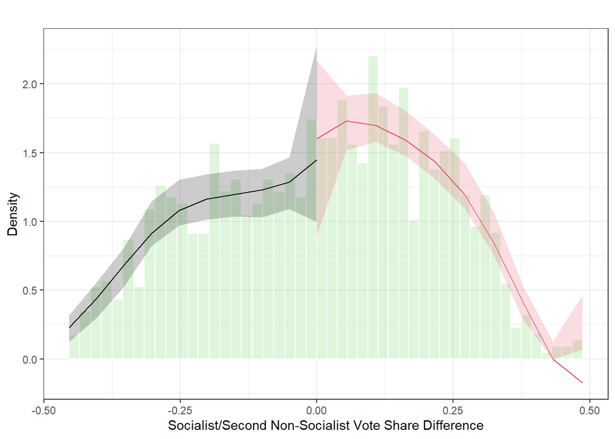

```
## $Estl
## Call: lpdensity
##
## Sample size                                      537
## Polynomial order for point estimation    (p=)    2
## Order of derivative estimated            (v=)    1
## Polynomial order for confidence interval (q=)    3
## Kernel function                                  triangular
## Scaling factor                                   0.461273666092943
## Bandwidth method                                 user provided
##
## Use summary(...) to show estimates.
##
## $Estr
## Call: lpdensity
##
## Sample size                                      626
## Polynomial order for point estimation    (p=)    2
## Order of derivative estimated            (v=)    1
## Polynomial order for confidence interval (q=)    3
## Kernel function                                  triangular
## Scaling factor                                   0.537865748709122
## Bandwidth method                                 user provided
##
## Use summary(...) to show estimates.
##
## $Estplot
```

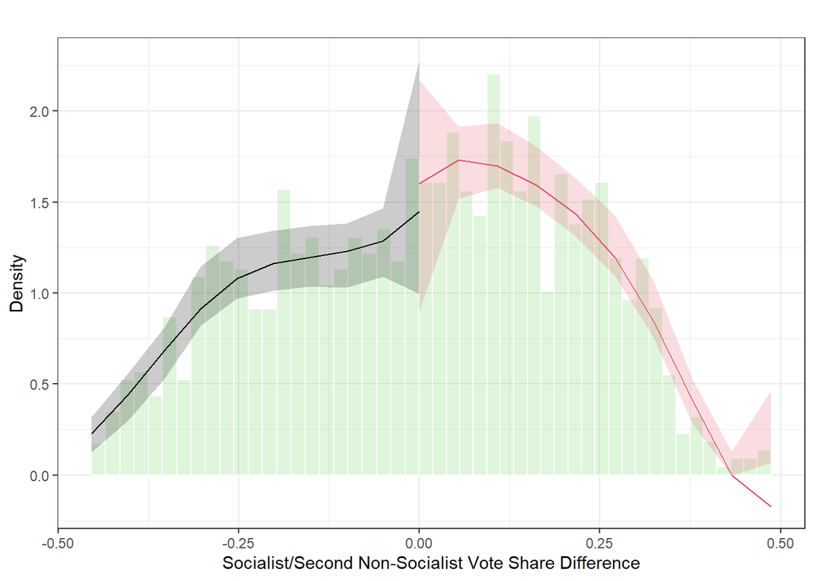

```r
# Figure A1

rdd <- rddensity(runoff$socmarg)

# png(filename="C:/Work/Dropbox/Papers/Soc_Threat/Paper/Final/selfselect.png")
rdplotdensity(rdd, runoff$socmarg, xlabel = "Socialist/Second Non-Socialist Vote Share Difference", ylabel = "Density")
```

```r
dev.off()
```

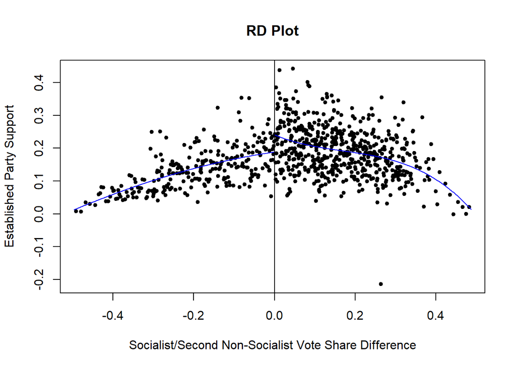

```r
### RDPlots

# Figure A2

# png(filename="C:/Work/Dropbox/Papers/Soc_Threat/Paper/Final/rdplot3.png")
rdplot(y = runoff$diffvotensoc, x = runoff$socmarg, p = 3, binselect = "qs", scale = 25,
       x.label = "Socialist/Second Non-Socialist Vote Share Difference",
       y.label = "Established Party Support")
```

```r
dev.off()
```

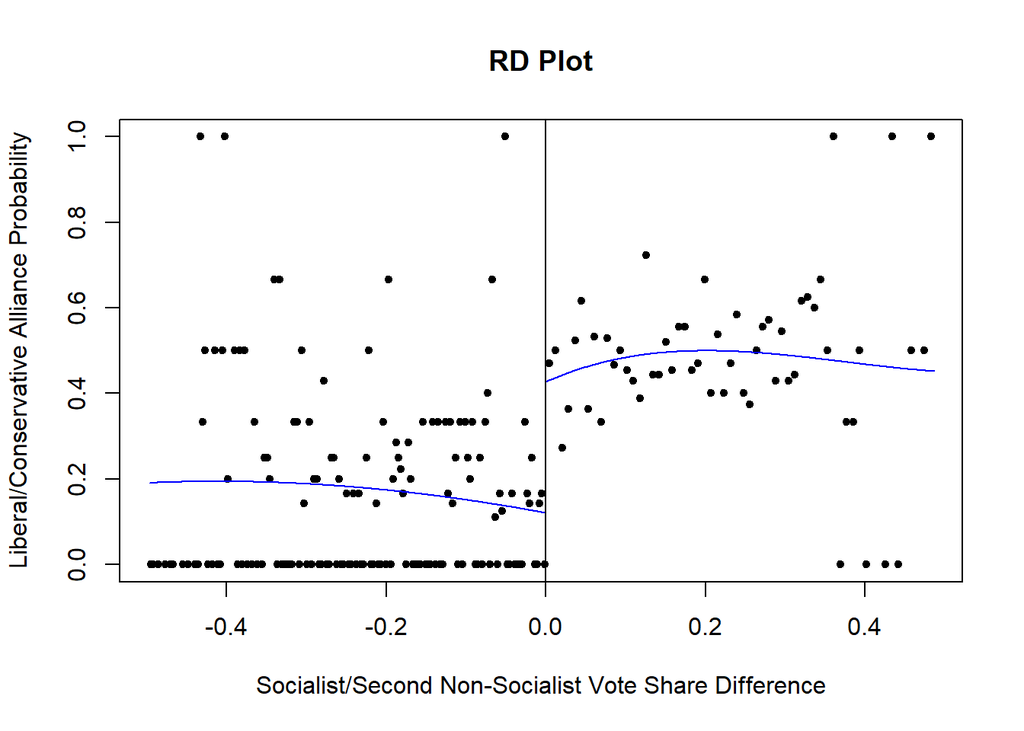

```r
# png(filename="C:/Work/Dropbox/Papers/Soc_Threat/Paper/Final/rdplot1.png")
rdplot(y = runoff$difcro, x = runoff$socmarg, p = 3, binselect = "es", scale = 20,
       x.label = "Socialist/Second Non-Socialist Vote Share Difference",
       y.label = "Liberal/Conservative Alliance Probability")
```

```r
dev.off()
```

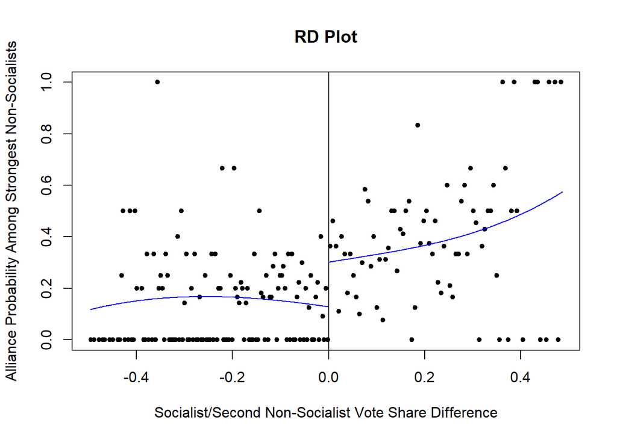

```r
# png(filename="C:/Work/Dropbox/Papers/Soc_Threat/Paper/Final/rdplot2.png")
rdplot(y = runoff$rightmar2, x = runoff$socmarg, p = 3, binselect = "es", scale = 20,
       x.label = "Socialist/Second Non-Socialist Vote Share Difference",
       y.label = "Alliance Probability Among Strongest Non-Socialists")
```

```r
dev.off()
```

## Main analysis

```r
## Loop for different bandwidths

# Liberal-conservative alliances (Figure 1a)

# resu <- list()
#
# for (i in 5:30){
#
#   libcon <- rdrobust(y = runoff$difcro2, x = runoff$socmarg,
#                      covs = cbind(runoff$lcomp,runoff$Year3, runoff$id, runoff$marg,runoff$lnonsocsup,runoff$clea,runoff$votensoc),
#                      all = T, cluster = runoff$Electoral_District_Number, h = i/100)
#
#   resu[[i]] <- c(libcon[[3]][[1]],libcon[[8]][[3]],libcon[[8]][[6]],i/100, sum(libcon[[22]]))
#
# }
```

From this point on I’m not able to replicate the paper further Error in crossprod(x, y) : requires numeric/complex matrix/vector arguments